# Ensembles I - Ensamblando un Random Forest

Alejandro Bolaños

2019-09-16

> Hay quienes pasan por el bosque y sólo ven leña para el fuego — León Tolstoi

El foco de nuestra clase de hoy es mostrarnos a nosotros mismos, que tenemos la capacidad de poder armar algoritmos funcionales útiles para la materia y para nuestro desarrollo profesional.

A la vez, veremos la potencia (y belleza) de los ensembles.

Construiremos con nuestras manos un Random Forest.

```r
rm( list=ls() )
gc()
```

```
##          used (Mb) gc trigger (Mb) max used (Mb)
## Ncells 510252 27.3    1147030 61.3   621665 33.3
## Vcells 974994  7.5    8388608 64.0  1600507 12.3
```

```r
library( "data.table" )

febrero  <-  fread("../datasets/201902.txt", header=TRUE, sep="\t")
abril <-  fread("../datasets/201904.txt", header=TRUE, sep="\t")

# Transformamos nuestra clase ternaria en una clase binaria
febrero$clase_binaria <- factor(ifelse(febrero$clase_ternaria == "BAJA+2", 1, 0))
abril$clase_binaria <- factor(ifelse(abril$clase_ternaria == "BAJA+2", 1, 0))

febrero$clase_ternaria <- NULL

# Sacamos el ID cliente y foto mes
febrero[, c("numero_de_cliente","foto_mes"):=NULL]

library( "ROCR" )
vsemilla <- c(810757,482071,340979,446441,917513)
```

Empecemos:

Lo primero que tenemos que ver es como vamos a tomar de forma aleatoria un conjunto de variables. A considerar:

- Arme una función que se llame `fseleccionarvariables(ds, clase, n)` donde: ** `n` se la cantidad de variables que necesitamos ** `ds` el conjunto de datos ** `clase` el nombre de la variable clase.
- Debe devolver un vector con el nombre de las variables seleccionadas, sin la variable clase
- Debe probar varias veces su función, antes de el siguiente paso.

```r
fseleccionarvariables <- function(ds, clase, n) {

  cm <- colnames(ds)
  cm <- cm[cm != clase]
  cm_select <- cm[sample(1:length(cm),n, replace=FALSE)]
  cm_select
}
```

```r
set.seed(vsemilla)
fseleccionarvariables(febrero, "clase_binaria", 15)
```

```
##  [1] "ttarjeta_visa"
##  [2] "ttarjeta_visa_debitos_automaticos"
##  [3] "internet"
##  [4] "Visa_madelantopesos"
##  [5] "Visa_msaldodolares"
##  [6] "mcomisiones_mantenimiento"
##  [7] "Master_madelantodolares"
##  [8] "mcheques_emitidos_rechazados"
##  [9] "mcuenta_corriente_Nopaquete"
## [10] "Master_mlimitecompra"
## [11] "Master_mpagado"
## [12] "Master_mconsumosdolares"
## [13] "ccomisiones_mantenimiento"
## [14] "mtransferencias_emitidas"
## [15] "tpaquete7"
```

```r
fseleccionarvariables(febrero, "clase_binaria", 15)
```

```
##  [1] "tautoservicio"                "mprestamos_prendarios"
##  [3] "tpaquete3"                    "ccheques_emitidos_rechazados"
##  [5] "tcallcenter"                  "Master_tadelantosefectivo"
##  [7] "ttarjeta_visa"                "mautoservicio"
##  [9] "tplazo_fijo"                  "mpagomiscuentas"
## [11] "tcajas"                       "minversiones_otras"
## [13] "tpaquete2"                    "ccambio_monedas_compra"
## [15] "mtarjeta_visa_consumo"
```

```r
fseleccionarvariables(febrero, "clase_binaria", 20)
```

```
##  [1] "tseguro_accidentes_personales"
##  [2] "mcaja_ahorro_Paquete"
##  [3] "Master_fultimo_cierre"
##  [4] "mpasivos_margen"
##  [5] "Visa_mpagosdolares"
##  [6] "Master_Fvencimiento"
##  [7] "mcuenta_corriente_Paquete"
##  [8] "mprestamos_prendarios"
##  [9] "tautoservicio"
## [10] "ttarjeta_visa_debitos_automaticos"
## [11] "Master_madelantopesos"
## [12] "Visa_marca_atraso"
## [13] "tpagodeservicios"
## [14] "cliente_vip"
## [15] "mttarjeta_visa_debitos_automaticos"
## [16] "Master_mconsumospesos"
## [17] "ccomisiones_mantenimiento"
## [18] "tplazo_fijo"
## [19] "tseguro_auto"
## [20] "Master_mpagospesos"
```

```r
fseleccionarvariables(febrero, "clase_binaria", 25)
```

```
##  [1] "tseguro_accidentes_personales"
##  [2] "Master_fechaalta"
##  [3] "tpaquete1"
##  [4] "ccomisiones_otras"
##  [5] "Visa_marca_atraso"
##  [6] "Master_mconsumospesos"
##  [7] "Visa_fechaalta"
##  [8] "tcaja_ahorro"
##  [9] "cliente_edad"
## [10] "mplazo_fijo_pesos"
## [11] "Master_madelantodolares"
## [12] "mfondos_comunes_inversion_dolares"
## [13] "tpaquete4"
## [14] "ccomisiones_mantenimiento"
## [15] "ccheques_depositados_rechazados"
## [16] "tpaquete5"
## [17] "mtarjeta_master_descuentos"
## [18] "tfondos_comunes_inversion"
## [19] "mautoservicio"
## [20] "mpasivos_margen"
## [21] "Master_Fvencimiento"
## [22] "mcambio_monedas_compra"
## [23] "Master_mfinanciacion_limite"
## [24] "Visa_msaldopesos"
## [25] "Master_mconsumosdolares"
```

El siguiente paso en nuestro *LRF* (Lego Random Forest), es tomar una muestra estratificada para el sampling del `bagging`.

- Arme una función `fbagging(ds, prop_train, prop_bagging, clase, n)` donde: ** `n` cantidad de muestras que necesitamos ** `ds` el conjunto de datos ** `prop_train` proporción que queremos para train ** `prop_bagging` proporción que queremos para bagging ** `clase` el nombre de la variable clase.
- Debe devolver una matriz donde cada columna es un sampling y cada registro tiene que tener 1, 2 ó 3. 1: Train, 2:Test, 3: OOB.
- Prueba repetidas veces la función y sus resultados.

```r
library(caret)
n <- 3
ds <- febrero
prop_train <- 0.7
pro_bagging <- 0.7
clase <- "clase_binaria"

fbagging <-
  function(ds,
           prop_train,
           prop_bagging,
           clase,
           n = 1,
           prefix = "s_"
           ) {

    respuesta <- matrix(0, ncol = n, nrow = dim(ds)[1])
    colnames(respuesta) <- paste0(prefix, 1:n)

    train_base <-
      createDataPartition(ds[, get(clase)], p = prop_train, list = FALSE)
    test_base   <-  (1:dim(ds)[1])[-train_base]


      respuesta[train_base,] <- 1
      respuesta[test_base,] <- 3

    for (i in 1:n) {
      oob <-
        createDataPartition(ds[train_base, get(clase)],
                            p = 1 - prop_bagging, list = FALSE)

      respuesta[train_base[oob], i] <- 2

    }
    respuesta

  }
```

Y probamos:

```r
test1 <- fbagging(febrero, 0.7, 0.7, "clase_binaria")

table(test1)
```

```
## test1
##     1     2     3
## 92051 39453 56357
```

Miramos las proporciones:

```r
table(test1) / dim(febrero)[1]
```

```
## test1
##         1         2         3
## 0.4899953 0.2100117 0.2999931
```

Revisamos que siempre `test` sea igual y tenga los mismos registros:

```r
test2 <- fbagging(febrero, 0.7, 0.7, "clase_binaria", n = 3)

test2 <- as.data.table(test2)

test2[s_1 == 3, .N]
```

```
## [1] 56357
```

```r
test2[s_1 == 3 & s_2 == 3, .N]
```

```
## [1] 56357
```

```r
test2[s_1 == 3 & s_2 == 3 & s_3 == 1, .N]
```

```
## [1] 0
```

```r
test2[s_1 == 3 & s_2 == 3 & s_3 == 3, .N]
```

```
## [1] 56357
```

Perfecto.

Pasamos a probar un árbol que vamos a usar dentro del bagging. Pero antes vamos a cargar nuestra `fmetricas` hecha solo para este caso, analicemos los cambios:

```r
fmetricas <- function(probabilidades, clases, label="") {

  # AUC
  binaria  <-  as.numeric(clases == "1")
  roc_pred <-  ROCR::prediction(probabilidades, binaria, label.ordering=c( 0, 1))
  auc_t <-  ROCR::performance( roc_pred,"auc");
  auc <- unlist(auc_t@y.values)


  data <- cbind(probabilidades,binaria)
  data <- as.data.table(data)
  data[, c("v", "c1", "c2") := list(
    ifelse(binaria == 1, 19500,-500),
    ifelse(binaria == 1, 1, 0),
    ifelse(binaria == 1, 0, 1))]
  data2 <- data[, .(gan = sum(v),
              cant1 = sum(c1),
              cant2=sum(c2)), by=probabilidades]
  setorder(data2,-probabilidades)
  data2[,c("gan2","quedan","sevan") := list(cumsum(gan),cumsum(cant2),cumsum(cant1))]

  ganancia <- data2[probabilidades >= 0.025, ][probabilidades == min(probabilidades), gan2]

  return(data.table(ganancia, auc, label))
}
```

Y finalmente probamos un árbol de los que luego, mucho van a construir nuestro bosque:

- Busque a mano cuales son los parámetros necesarios para que abran los árboles. Ejecute varias veces hasta estar seguro que siempre van a haber árboles con los parámetros que eligió.

```r
library(rpart)

# Complete: N
set.seed(vsemilla[1])
var1 <- fseleccionarvariables(febrero, "clase_binaria", 20)
for1 <- formula(paste("clase_binaria", "~", paste0(var1, collapse = " + ")))
sb1 <- fbagging(febrero, 0.7, 0.7, "clase_binaria")

t0 <- Sys.time()
modelo <- rpart(for1, data = febrero[sb1[,1] == 1, ],
                # Complete: ms mb md cp
                minsplit=10,
                minbucket=5,
                maxdepth = 20,
                cp = 0,
                xval=0
                )

t1 <- Sys.time()
tiempo <-  as.numeric(  t1 - t0, units = "secs")

modelo
```

```
## n= 92051
##
## node), split, n, loss, yval, (yprob)
##       * denotes terminal node
##
##      1) root 92051 531 0 (0.994231459 0.005768541)
##        2) ttarjeta_visa>=0.5 88403 313 0 (0.996459396 0.003540604)
##          4) mcomisiones_mantenimiento>=-4619.79 88395 310 0 (0.996493014 0.003506986)
##            8) internet>=0.5 80201 201 0 (0.997493797 0.002506203) *
##            9) internet< 0.5 8194 109 0 (0.986697584 0.013302416)
##             18) mcomisiones_mantenimiento>=-1711.995 8177 105 0 (0.987159105 0.012840895)
##               36) mtransferencias_emitidas>=0.015 794   0 0 (1.000000000 0.000000000) *
##               37) mtransferencias_emitidas< 0.015 7383 105 0 (0.985778139 0.014221861)
##                 74) ttarjeta_visa_debitos_automaticos>=3.5 945   4 0 (0.995767196 0.004232804) *
##                 75) ttarjeta_visa_debitos_automaticos< 3.5 6438 101 0 (0.984311898 0.015688102)
##                  150) mcomisiones_mantenimiento< 708.495 3754  45 0 (0.988012786 0.011987214) *
##                  151) mcomisiones_mantenimiento>=708.495 2684  56 0 (0.979135618 0.020864382)
##                    302) Master_mlimitecompra>=323043.4 226   0 0 (1.000000000 0.000000000) *
##                    303) Master_mlimitecompra< 323043.4 2458  56 0 (0.977217250 0.022782750)
##                      606) Visa_msaldodolares>=45.385 137   0 0 (1.000000000 0.000000000) *
##                      607) Visa_msaldodolares< 45.385 2321  56 0 (0.975872469 0.024127531)
##                       1214) Visa_msaldodolares< 21.9 2314  55 0 (0.976231634 0.023768366)
##                         2428) mcomisiones_mantenimiento< 1416.48 2303  54 0 (0.976552323 0.023447677)
##                           4856) mprestamos_prendarios>=5670.5 68   0 0 (1.000000000 0.000000000) *
##                           4857) mprestamos_prendarios< 5670.5 2235  54 0 (0.975838926 0.024161074)
##                             9714) tcallcenter>=0.5 129   1 0 (0.992248062 0.007751938) *
##                             9715) tcallcenter< 0.5 2106  53 0 (0.974833808 0.025166192)
##                              19430) mcomisiones_mantenimiento< 777.815 1357  30 0 (0.977892410 0.022107590) *
##                              19431) mcomisiones_mantenimiento>=777.815 749  23 0 (0.969292390 0.030707610)
##                                38862) ttarjeta_visa_debitos_automaticos>=1.5 119   0 0 (1.000000000 0.000000000) *
##                                38863) ttarjeta_visa_debitos_automaticos< 1.5 630  23 0 (0.963492063 0.036507937)
##                                  77726) mcomisiones_mantenimiento>=845.495 468  14 0 (0.970085470 0.029914530) *
##                                  77727) mcomisiones_mantenimiento< 845.495 162   9 0 (0.944444444 0.055555556)
##                                   155454) Master_mlimitecompra< 38610 144   7 0 (0.951388889 0.048611111)
##                                     310908) ttarjeta_visa_debitos_automaticos< 0.5 98   3 0 (0.969387755 0.030612245)
##                                       621816) Master_mlimitecompra< 26325 38   0 0 (1.000000000 0.000000000) *
##                                       621817) Master_mlimitecompra>=26325 38   1 0 (0.973684211 0.026315789) *
##                                     310909) ttarjeta_visa_debitos_automaticos>=0.5 46   4 0 (0.913043478 0.086956522) *
##                                   155455) Master_mlimitecompra>=38610 18   2 0 (0.888888889 0.111111111) *
##                         2429) mcomisiones_mantenimiento>=1416.48 11   1 0 (0.909090909 0.090909091) *
##                       1215) Visa_msaldodolares>=21.9 7   1 0 (0.857142857 0.142857143) *
##             19) mcomisiones_mantenimiento< -1711.995 17   4 0 (0.764705882 0.235294118) *
##          5) mcomisiones_mantenimiento< -4619.79 8   3 0 (0.625000000 0.375000000) *
##        3) ttarjeta_visa< 0.5 3648 218 0 (0.940241228 0.059758772)
##          6) internet>=0.5 2442  83 0 (0.966011466 0.033988534) *
##          7) internet< 0.5 1206 135 0 (0.888059701 0.111940299)
##           14) mcheques_emitidos_rechazados< 8775 1199 131 0 (0.890742285 0.109257715) *
##           15) mcheques_emitidos_rechazados>=8775 7   3 1 (0.428571429 0.571428571) *
```

Vemos que nuestros árboles al ser más chicos, tardan mucho menos en entrenar.

```r
tiempo
```

```
## [1] 2.108352
```

Medimos la calidad del modelo:

```r
train_prediccion <- as.data.frame(predict(modelo, febrero[sb1[,1] == 1,] , type = "prob"))
test_prediccion <- as.data.frame(predict(modelo, febrero[sb1[,1] == 3,] , type = "prob"))
oob_prediccion <- as.data.frame(predict(modelo, febrero[sb1[,1] == 2,] , type = "prob"))

f1 <- fmetricas(train_prediccion$`1`, febrero[sb1[,1] == 1,"clase_binaria"], "train")
f2 <- fmetricas(test_prediccion$`1`, febrero[sb1[,1] == 3,"clase_binaria"], "test")
f3 <- fmetricas(oob_prediccion$`1`, febrero[sb1[,1] == 2,"clase_binaria"], "oob")

rbindlist(list(f1,f2,f3))
```

| ganancia | auc | label |
| --- | --- | --- |
| 2858500 | 0.7750730 | train |
| 1408000 | 0.7490395 | test |
| 1283500 | 0.7633429 | oob |

Sabemos que vamos a tener que ejecutar esto multiples veces. Tenemos que resolver como acumulamos las probabilidades para despues promediarlas debidamente. Esto podemos resolverlo con una matriz de probabilidades:

```r
cantidad_iteraciones <- 1
matriz_prob <- matrix(0, ncol = cantidad_iteraciones, nrow = dim(febrero)[1])
```

Y la completamos de forma correcta:

```r
matriz_prob[sb1[,1] == 1] <- train_prediccion$`1`
matriz_prob[sb1[,1] == 3] <- test_prediccion$`1`
matriz_prob[sb1[,1] == 2] <- oob_prediccion$`1`
```

Y probamos que esté todo bien:

```r
f1 <- fmetricas(matriz_prob[sb1[,1] == 1], febrero[sb1[,1] == 1,"clase_binaria"], "train")
f2 <- fmetricas(matriz_prob[sb1[,1] == 3], febrero[sb1[,1] == 3,"clase_binaria"], "test")
f3 <- fmetricas(matriz_prob[sb1[,1] == 2], febrero[sb1[,1] == 2,"clase_binaria"], "oob")

rbindlist(list(f1,f2,f3))
```

| ganancia | auc | label |
| --- | --- | --- |
| 2858500 | 0.7750730 | train |
| 1408000 | 0.7490395 | test |
| 1283500 | 0.7633429 | oob |

Ahora probamos de ejecutar todo lo anterior para un número controlado de árboles:

```r
cantidad_iteraciones <- 5
matriz_prob <-
  matrix(0, ncol = cantidad_iteraciones, nrow = dim(febrero)[1])
colnames(matriz_prob)<-paste0("p_",1:cantidad_iteraciones)

sb2 <-
  fbagging(febrero, 0.7, 0.7, "clase_binaria", n = cantidad_iteraciones)

t0 <- Sys.time()
for (i in 1:cantidad_iteraciones) {
  var2 <- fseleccionarvariables(febrero, "clase_binaria", 20)
  for2 <-
    formula(paste("clase_binaria", "~", paste0(var2, collapse = " + ")))

  modelo2 <- rpart(
    for2,
    data = febrero[sb2[, i] == 1,],
    # Complete: ms mb md cp
    minsplit = 10,
    minbucket = 5,
    maxdepth = 20,
    cp = 0,
    xval = 0
  )

  train_prediccion <-
    as.data.frame(predict(modelo2, febrero[sb2[, 1] == 1, ] , type = "prob"))
  test_prediccion <-
    as.data.frame(predict(modelo2, febrero[sb2[, 1] == 3, ] , type = "prob"))
  oob_prediccion <-
    as.data.frame(predict(modelo2, febrero[sb2[, 1] == 2, ] , type = "prob"))

  matriz_prob[sb2[, i] == 1, i] <- train_prediccion$`1`
  matriz_prob[sb2[, i] == 3, i] <- test_prediccion$`1`
  matriz_prob[sb2[, i] == 2, i] <- oob_prediccion$`1`

}
t1 <- Sys.time()
tiempo <-  as.numeric(t1 - t0, units = "secs")
tiempo
```

```
## [1] 11.45532
```

Ahora vamos a realizar el ensemble. Para esto simplemente vamos a promediar la probabilidad. Tenemos que mirar los siguientes puntos.

- Vamos a combinar de la siguiente forma: 1, (1,2), (1,2,3), etc… para ver la mejora.
- En el `train` y en el `oob` no siempre van a estar los mismos elementos.

Por el simple motivo de no hacer muy complejo el código, sólo veamos los ensembles sobre `test`. Dejando al alumno la misma tarea para el resto.

```r
matriz_ensemble_test <-
  matrix(0, ncol = cantidad_iteraciones - 1, nrow = dim(febrero)[1])
colnames(matriz_ensemble_test)<-paste0("e_",2:cantidad_iteraciones)

matriz_prob_test <- matriz_prob

matriz_prob_test[sb2 == 1 | sb2 == 2] <- NA

for(i in 2:cantidad_iteraciones) {
    matriz_ensemble_test[,i - 1] <-rowMeans(matriz_prob_test[,1:i], na.rm = TRUE)
}
```

Veamos el resultado:

```r
head(matriz_ensemble_test)
```

```
##              e_2         e_3         e_4         e_5
## [1,] 0.002260041 0.001957169 0.010118396 0.008936042
## [2,] 0.004262376 0.005538837 0.004862617 0.004731419
## [3,]         NaN         NaN         NaN         NaN
## [4,]         NaN         NaN         NaN         NaN
## [5,] 0.002260041 0.001957169 0.002176366 0.001987261
## [6,]         NaN         NaN         NaN         NaN
```

Con una lógica similar, y con cuidado de los NaN, se puede contruir las tablas para el `train` y el `oob`.

Ahora sacamos las métricas de cada ensemble.

```r
resultados <- data.table()
for (i in 1:(cantidad_iteraciones-1)) {

  r <- cbind(fmetricas(matriz_ensemble_test[sb2[,1] == 3, i],
                 febrero[sb2[,1] == 3, clase_binaria],
                 label=paste("test e", i + 1)),i)

  resultados <- rbindlist(list(resultados,r))

}
resultados
```

| ganancia | auc | label | i |
| --- | --- | --- | --- |
| 1821500 | 0.8311500 | test e 2 | 1 |
| 2092500 | 0.8624820 | test e 3 | 2 |
| 2322500 | 0.8745234 | test e 4 | 3 |
| 2227000 | 0.8735402 | test e 5 | 4 |

Vaya, me muestra que va mejorando! Seamos más ambiciosos, subamos el `n`, pero guardemos los modelos, para aplicarlos sobre `abril`.

```r
cantidad_iteraciones <- 50
matriz_prob <-
  matrix(0, ncol = cantidad_iteraciones, nrow = dim(febrero)[1])
colnames(matriz_prob)<-paste0("p_",1:cantidad_iteraciones)

sb3 <-
  fbagging(febrero, 0.7, 0.7, "clase_binaria", n = cantidad_iteraciones)

modelos <- list()

t0 <- Sys.time()
for (i in 1:cantidad_iteraciones) {
  var3 <- fseleccionarvariables(febrero, "clase_binaria", 20)
  for3 <-
    formula(paste("clase_binaria", "~", paste0(var3, collapse = " + ")))

  modelo3 <- rpart(
    for3,
    data = febrero[sb3[, i] == 1,],
    minsplit = 10,
    minbucket = 5,
    maxdepth = 20,
    cp = 0,
    xval = 0
  )

  modelos[[i]] <- modelo3

  test_prediccion <-
    as.data.frame(predict(modelo3, febrero[sb3[, i] == 3, ] , type = "prob"))

  matriz_prob[sb3[, i] == 3, i] <- test_prediccion$`1`

}
t1 <- Sys.time()
tiempo <-  as.numeric(t1 - t0, units = "secs")
tiempo
```

```
## [1] 69.77994
```

Medimos su evolución:

```r
matriz_ensemble_test <-
  matrix(0, ncol = cantidad_iteraciones - 1, nrow = dim(febrero)[1])
colnames(matriz_ensemble_test)<-paste0("e_",2:cantidad_iteraciones)

matriz_prob_test <- matriz_prob

matriz_prob_test[sb3 == 1 | sb3 == 2] <- NA

for(i in 2:cantidad_iteraciones) {
    matriz_ensemble_test[,i - 1] <-rowMeans(matriz_prob_test[,1:i], na.rm = TRUE)
}

resultados <- data.table()
for (i in 1:(cantidad_iteraciones-1)) {

  r <- cbind(fmetricas(matriz_ensemble_test[sb3[,1] == 3, i],
                 febrero[sb3[,1] == 3, clase_binaria],
                 label=paste("test e", i + 1)),i)

  resultados <- rbindlist(list(resultados,r))

}
resultados
```

| ganancia | auc | label | i |
| --- | --- | --- | --- |
| 1907500 | 0.8977638 | test e 2 | 1 |
| 2060500 | 0.8971744 | test e 3 | 2 |
| 2073500 | 0.8997105 | test e 4 | 3 |
| 2287500 | 0.9030313 | test e 5 | 4 |
| 2316500 | 0.9059721 | test e 6 | 5 |
| 2455500 | 0.9053038 | test e 7 | 6 |
| 2512000 | 0.9058536 | test e 8 | 7 |
| 2391500 | 0.9088191 | test e 9 | 8 |
| 2398000 | 0.9100230 | test e 10 | 9 |
| 2474500 | 0.9132261 | test e 11 | 10 |

[output cut: 39 more lines]

Buscamos la ganancia máxima:

```r
resultados[ganancia==max(ganancia)]
```

| ganancia | auc | label | i |
| --- | --- | --- | --- |
| 2687500 | 0.9207832 | test e 48 | 47 |

Y la ponderamos:

```r
resultados[ganancia==max(ganancia), ganancia/0.3]
```

```
## [1] 8958333
```

Y lo graficamos para que se vea lindo:

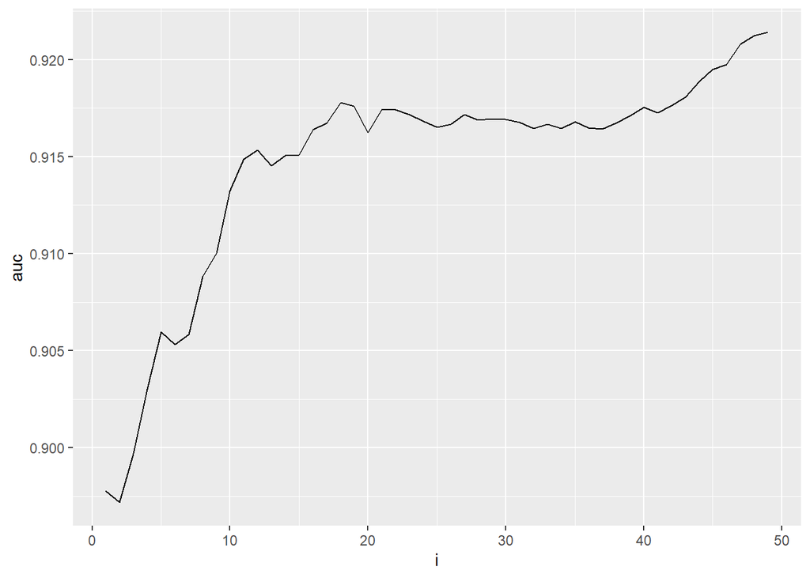

```r
library(ggplot2)

ggplot(resultados, aes(i,auc)) + geom_line()
```

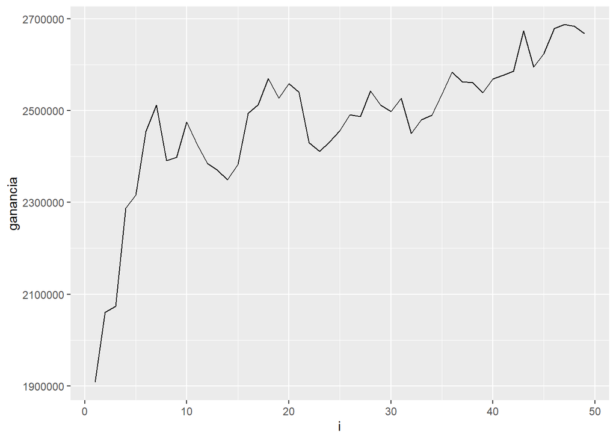

```r
ggplot(resultados, aes(i,ganancia)) + geom_line()
```

Reflexión. Con un minuto de ejecución. Un solo minuto de ejecución conseguimos una auc superior a 0.92 y una ganancia normalizada de `8958333`, algo más de 1mm más que la mejor lograda con un solo árbol, después de dejarlo un monton de tiempo buscando hiperparámetros!!!.

Aplicamos el modelo a `abril`:

```r
matriz_abril <-
  matrix(0, ncol = cantidad_iteraciones, nrow = dim(abril)[1])

colnames(matriz_abril)<-paste0("p_",1:cantidad_iteraciones)

for (i in 1:cantidad_iteraciones) {
  abril_prediccion <- as.data.frame(predict(modelos[[i]], abril, type = "prob"))
  matriz_abril[,i] <- abril_prediccion$`1`
}


matriz_ensemble_abril <-
  matrix(0, ncol = cantidad_iteraciones - 1, nrow = dim(abril)[1])
colnames(matriz_ensemble_abril)<-paste0("e_",2:cantidad_iteraciones)

for(i in 2:cantidad_iteraciones) {
    matriz_ensemble_abril[,i - 1] <-rowMeans(matriz_abril[,1:i], na.rm = TRUE)
}

resultados_abril <- data.table()
for (i in 1:(cantidad_iteraciones-1)) {

  r <- cbind(fmetricas(matriz_ensemble_abril[, i],
                 abril[, clase_binaria],
                 label=paste("abril e", i + 1)),i)

  resultados_abril <- rbindlist(list(resultados_abril,r))

}
resultados_abril
```

| ganancia | auc | label | i |
| --- | --- | --- | --- |
| 5114000 | 0.8997534 | abril e 2 | 1 |
| 5457500 | 0.9055118 | abril e 3 | 2 |
| 5274000 | 0.9056749 | abril e 4 | 3 |
| 5729500 | 0.9063325 | abril e 5 | 4 |
| 6029000 | 0.9092642 | abril e 6 | 5 |
| 6027000 | 0.9075902 | abril e 7 | 6 |
| 5958500 | 0.9060900 | abril e 8 | 7 |
| 5884000 | 0.9059828 | abril e 9 | 8 |
| 5948000 | 0.9075022 | abril e 10 | 9 |
| 6108500 | 0.9099980 | abril e 11 | 10 |

[output cut: 39 more lines]

Y nuevamente graficamos:

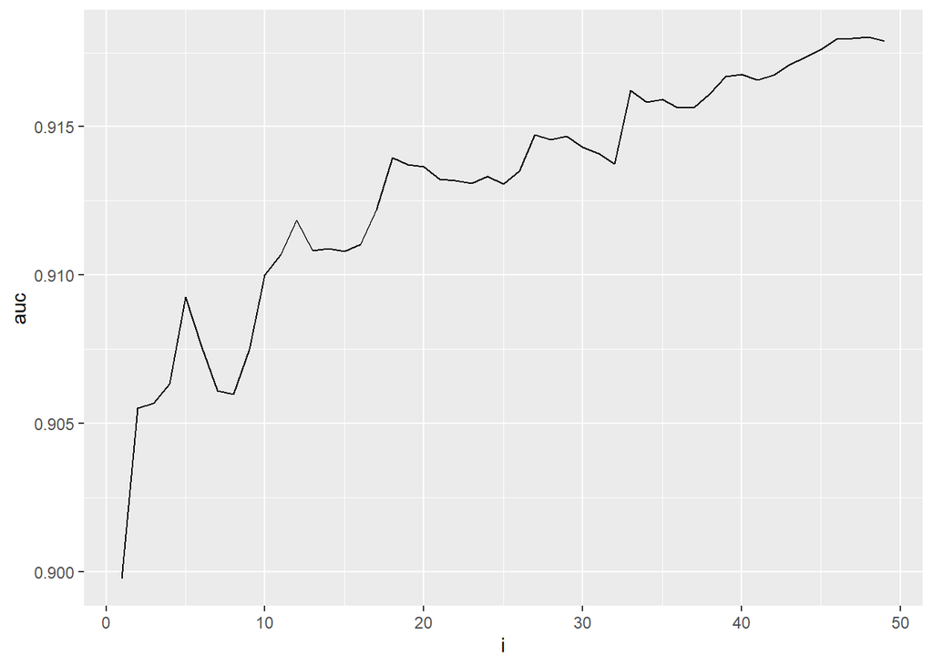

```r
ggplot(resultados_abril, aes(i,auc)) + geom_line()
```

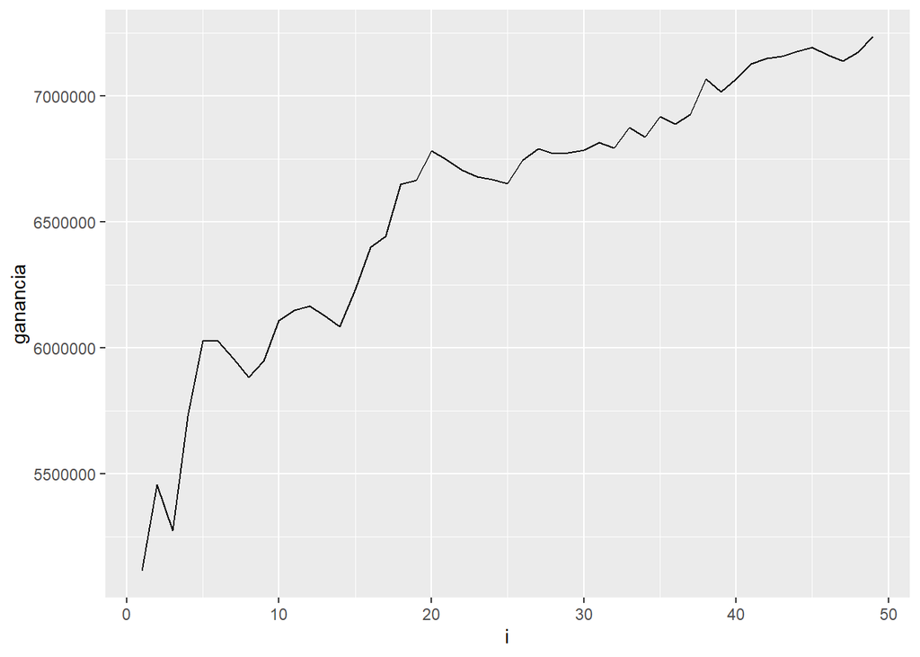

```r
ggplot(resultados_abril, aes(i,ganancia)) + geom_line()
```

Tarea:

Queda tanto, tanto por mejorar, que dejo al alumno que se aventure por donde su instinto lo guie.